# Ch. 2

Working example for exposure assessment using 1-km annuli

January 20, 2020

This working example demonstrates how to assess exposure using 1-km annuli. I drew a subset of well data from the DrillingInfo dataset for well sites in Signal Hill, California, around two mock residence locations.

### Data

#### Map. Visualization of well sites in Signal Hill, California, and mock residence locations

I selected well sites in 20 km buffer around mock residence locations (triangles). Well sites preproduction during the study period are orange, and sites in production are gray. The mock residences are the locations of actual residences randomly selected based on a visual inspection of Google Maps and are not associated with any protected datasets.

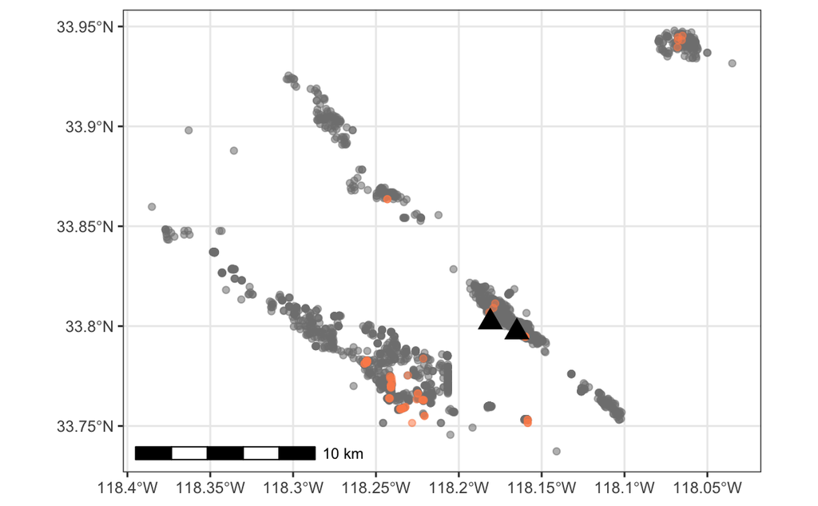

### Exposure Assessment

#### Map. Visualization of the 1-km annuli around mock residence location, out to 10 km from the residence

This simulates what exposure data may look like for women included in the dataset. This map shows all well sites that were in preproduction or production from 1997 to 2011. Many of these wells may not have overlapped temporally with the gestational period for the birth. The residence location and duration of pregnancy are both mock data and not drawn from a protected dataset. The wells data are real and drawn from DrillingInfo for well sites in Signal Hill, California.

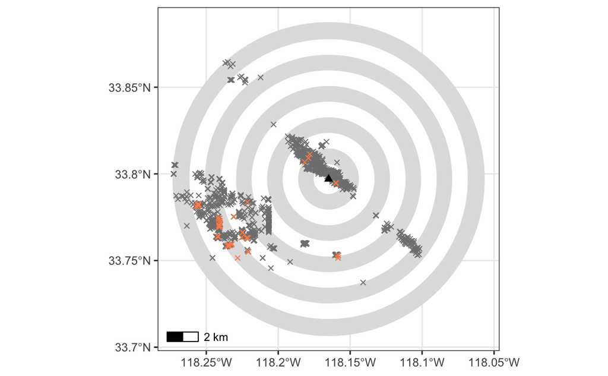

#### Map. Visualization of 1-km annuli around mock residence location with well sites in preproduction or production during time of gestation

Note: The residence location and duration of pregnancy are both mock data and not drawn from a protected dataset. The wells data are real and drawn from DrillingInfo for well sites in Signal Hill, California.

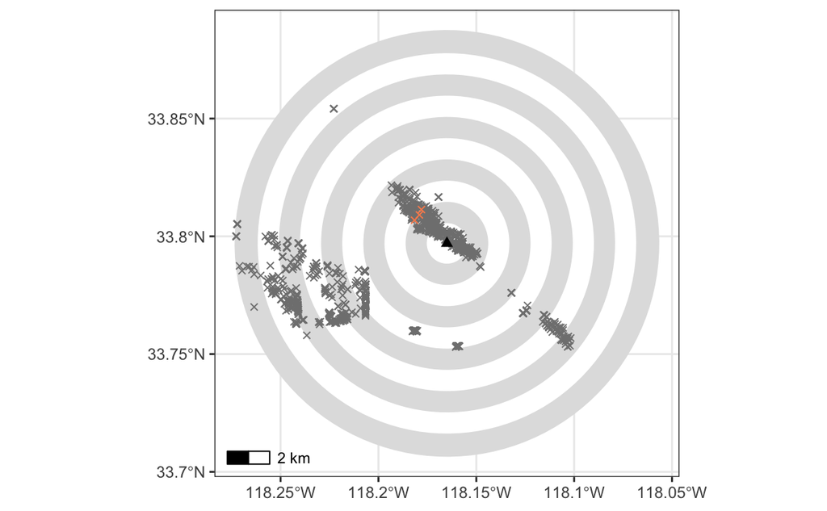

#### Function

For each input residence location, this function counts the number of wells in 1-km radius annuli (i.e., bins) out to 10 km. To consider: make this function generalizable by adding an input for radius_interval and radius_max, and generate the annuli in a looping function.

```r
# takes residence coordinates ('point') as an sf object, generates 1-km annuli
# around the point out to 10 km, and counts the number of well sites, both
# in the preproduction and production stages, within each annulus
assessExposureAnnuliGeneral <- function(point,  # sf object
                                        county_wells) {
  # makes annuli around the point

    # initializes annuli as buffers
    annulus0to1 <- point %>%
      st_transform(crs_projected) %>%
      st_buffer(dist = 1000) %>%
      st_transform(crs_nad83)
    annulus1to2 <- point %>%
      st_transform(crs_projected) %>%
      st_buffer(dist = 2000) %>%
      st_transform(crs_nad83)
    annulus2to3 <- point %>%
      st_transform(crs_projected) %>%
      st_buffer(dist = 3000) %>%
      st_transform(crs_nad83)
    annulus3to4 <- point %>%
      st_transform(crs_projected) %>%
      st_buffer(dist = 4000) %>%
      st_transform(crs_nad83)
    annulus4to5 <- point %>%
      st_transform(crs_projected) %>%
      st_buffer(dist = 5000) %>%
      st_transform(crs_nad83)
    annulus5to6 <- point %>%
      st_transform(crs_projected) %>%
      st_buffer(dist = 6000) %>%
      st_transform(crs_nad83)
    annulus6to7 <- point %>%
      st_transform(crs_projected) %>%
      st_buffer(dist = 7000) %>%
      st_transform(crs_nad83)
    annulus7to8 <- point %>%
      st_transform(crs_projected) %>%
      st_buffer(dist = 8000) %>%
      st_transform(crs_nad83)
    annulus8to9 <- point %>%
      st_transform(crs_projected) %>%
      st_buffer(dist = 9000) %>%
      st_transform(crs_nad83)
    annulus9to10 <- point %>%
      st_transform(crs_projected) %>%
      st_buffer(dist = 10000) %>%
      st_transform(crs_nad83)

    # finalizes annuli by successively clipping differences in reverse order
    annulus9to10 <- st_difference(annulus9to10, annulus8to9)
    annulus8to9 <- st_difference(annulus8to9, annulus7to8)
    annulus7to8 <- st_difference(annulus7to8, annulus6to7)
    annulus6to7 <- st_difference(annulus6to7, annulus5to6)
    annulus5to6 <- st_difference(annulus5to6, annulus4to5)
    annulus4to5 <- st_difference(annulus4to5, annulus3to4)
    annulus3to4 <- st_difference(annulus3to4, annulus2to3)
    annulus2to3 <- st_difference(annulus2to3, annulus1to2)
    annulus1to2 <- st_difference(annulus1to2, annulus0to1)

  # prepares wells data

    # makes mask to clip wells
    point_mask <- point %>%
      # transforms into projected CRS for buffering
      st_transform(crs_projected) %>%
      # makes 10,000 m (10 km) buffer
      st_buffer(dist = 10000) %>%
      # merges polygons into one
      st_union() %>%
      # transforms back to primary project CRS
      st_transform(crs_nad83)

  # subsets to wells that intersect with 'point_mask'  i.e., within 10 km of
  # the maternal residence, and that have preproduction/production period
  # that overlaps with the gestation interval

    # well sites in preproduction stage
    wells_preprod_within_10km <- county_wells %>%
      filter(drilled_1997_to_2011 == 1) %>%
      st_intersection(point_mask) %>%
      mutate(exposed = int_overlaps(point$gestation_interval,
                                    drilling_interval)) %>%
      filter(exposed == 1)

  # well sites in production stage
    wells_prod_within_10km <- county_wells %>%
      filter(prod_1997_to_2011 == 1) %>%
      st_intersection(point_mask) %>%
      mutate(exposed = int_overlaps(point$gestation_interval,
                                    prod_interval)) %>%
      filter(exposed == 1)

  # counts and stores number of well sites, in the preproduction and production
  # stages, within each annulus
  point <- point %>%

    # counts well sites in preproduction stage in each annulus
    mutate(wells_preprod_0to1km =
             sum(unlist(st_intersects(wells_preprod_within_10km, annulus0to1))),
           wells_preprod_1to2km =
             sum(unlist(st_intersects(wells_preprod_within_10km, annulus1to2))),
           wells_preprod_2to3km =
             sum(unlist(st_intersects(wells_preprod_within_10km, annulus2to3))),
           wells_preprod_3to4km =
             sum(unlist(st_intersects(wells_preprod_within_10km, annulus3to4))),
           wells_preprod_4to5km =
             sum(unlist(st_intersects(wells_preprod_within_10km, annulus4to5))),
           wells_preprod_5to6km =
             sum(unlist(st_intersects(wells_preprod_within_10km, annulus5to6))),
           wells_preprod_6to7km =
             sum(unlist(st_intersects(wells_preprod_within_10km, annulus6to7))),
           wells_preprod_7to8km =
             sum(unlist(st_intersects(wells_preprod_within_10km, annulus7to8))),
           wells_preprod_8to9km =
             sum(unlist(st_intersects(wells_preprod_within_10km, annulus8to9))),
           wells_preprod_9to10km =
             sum(unlist(st_intersects(wells_preprod_within_10km, annulus9to10)))) %>%

    # well sites in production stage in each annulus
    mutate(wells_prod_0to1km =
             sum(unlist(st_intersects(wells_prod_within_10km, annulus0to1))),
           wells_prod_1to2km=
             sum(unlist(st_intersects(wells_prod_within_10km, annulus1to2))),
           wells_prod_2to3km =
             sum(unlist(st_intersects(wells_prod_within_10km, annulus2to3))),
           wells_prod_3to4km =
             sum(unlist(st_intersects(wells_prod_within_10km, annulus3to4))),
           wells_prod_4to5km =
             sum(unlist(st_intersects(wells_prod_within_10km, annulus4to5))),
           wells_prod_5to6km =
             sum(unlist(st_intersects(wells_prod_within_10km, annulus5to6))),
           wells_prod_6to7km =
             sum(unlist(st_intersects(wells_prod_within_10km, annulus6to7))),
           wells_prod_7to8km =
             sum(unlist(st_intersects(wells_prod_within_10km, annulus7to8))),
           wells_prod_8to9km =
             sum(unlist(st_intersects(wells_prod_within_10km, annulus8to9))),
           wells_prod_9to10km =
             sum(unlist(st_intersects(wells_prod_within_10km, annulus9to10))))

  # returns the well count data
  return(point)
}
```

**Testing exposure assessment function call.** Calls the assessExposureAnnuli() function for one of the sample maternal residence points and shows output. This is the same point as illustrated in the figure above.

```r
# calls function
  point_out <- assessExposureAnnuliGeneral(point, county_wells)
# shows output
  glimpse(point_out)
```

```
Observations: 1
Variables: 23
$ id                    <dbl> 1
$ gestation_interval    <Interval> 2004-07-01 UTC--2005-04-30 UTC
$ geometry              <POINT [°]> POINT (-118.165 33.797)
$ wells_preprod_0to1km  <int> 0
$ wells_preprod_1to2km  <int> 3
$ wells_preprod_2to3km  <int> 0
$ wells_preprod_3to4km  <int> 0
$ wells_preprod_4to5km  <int> 0
$ wells_preprod_5to6km  <int> 0
$ wells_preprod_6to7km  <int> 0
$ wells_preprod_7to8km  <int> 0
$ wells_preprod_8to9km  <int> 0
$ wells_preprod_9to10km <int> 0
$ wells_prod_0to1km     <int> 125
$ wells_prod_1to2km     <int> 135
$ wells_prod_2to3km     <int> 65
$ wells_prod_3to4km     <int> 29
$ wells_prod_4to5km     <int> 168
$ wells_prod_5to6km     <int> 62
$ wells_prod_6to7km     <int> 104
$ wells_prod_7to8km     <int> 108
$ wells_prod_8to9km     <int> 66
$ wells_prod_9to10km    <int> 22
```

The function produced the expected output. The next step is to move the code to the server and write a function to call the general function above in a loop, capture the output in a list, convert the list object to a tibble, and export the resulting dataset as a CSV file. The exported CSV shoulud have birth_id and the well count vectors for each annulus.